# Assignment - Coursera Practical ML

Abhishek Srivastava

October 18, 2015

#### Step 1 - **Loading the required R packages**

```r
  library(caret)
  library(dplyr)
  library(rpart)
  library(e1071)
  library(randomForest)
```

#### Step 2- **Reading the data**

Read the training and test data from the given csv files in two dataframe

```r
set.seed(3523)
setwd("D:/Users/abhishe6/Desktop/Abhi/ML/Machine")
training <- read.csv(file="pml-training.csv", header=TRUE, sep=",",na.strings=c("#DIV/0!"," ", "", "NA", "NAs", "NULL"))
testing <- read.csv(file="pml-testing.csv", header=TRUE, sep=",",na.strings=c("#DIV/0!"," ", "", "NA", "NAs", "NULL"))
```

#### Step 3- **Cleaning the training data**

Training data is cleaned by performing following operations-  
* Removing the column with large no of NA values.  
* Removing the column with Zero variance.  
* A quicklook through dataset reveals that the columnn with name X, user_name, raw_timestamp_part_1, raw_timestamp_part_2, cvtd_timestamp, new_window, num_window should have no use for the Model building.

```r
clean_training <- training[,colSums(is.na(training))== 0]
zerovariance  <- nearZeroVar(clean_training[sapply(clean_training, is.numeric)], saveMetrics=TRUE)
clean_training <- clean_training[, zerovariance[, 'nzv'] == 0]
features_training <- select(clean_training,- X, - user_name, - raw_timestamp_part_1,- raw_timestamp_part_2,
                              - cvtd_timestamp, - new_window,-  num_window )
```

#### Step 4- **Data slicing**

A 75:25 split for the training and testing set is performed here.

```r
inTrain <- createDataPartition(y=features_training$classe,p=0.75,list=FALSE)
training <- features_training[inTrain,]
test <- features_training[-inTrain,]
```

#### Step 5- **Model building**

##### *Using rpart*

First a rpart Model is built on the training set. 5 fold cross validation is applied to prevent overfitting.

```r
rpartModel <- train(classe ~.,data = training,method="rpart",trControl=trainControl(method="cv",number=5),tuneLength=50)
rpartModel
```

```
## CART
##
## 14718 samples
##    52 predictor
##     5 classes: 'A', 'B', 'C', 'D', 'E'
##
## No pre-processing
## Resampling: Cross-Validated (5 fold)
## Summary of sample sizes: 11775, 11773, 11776, 11774, 11774
## Resampling results across tuning parameters:
##
##   cp           Accuracy   Kappa       Accuracy SD  Kappa SD
##   0.001234216  0.8899998  0.86081802  0.004719165  0.005990637
##   0.001329156  0.8859908  0.85572245  0.007596190  0.009646803
##   0.001424096  0.8840201  0.85322690  0.006746065  0.008573507
##   0.001471566  0.8817784  0.85038498  0.006888886  0.008745197
##   0.001519035  0.8813707  0.84986661  0.007502011  0.009526476
##   0.001613975  0.8775652  0.84501811  0.009230793  0.011719520
##   0.001708915  0.8733527  0.83967685  0.010164421  0.012853716
##   0.001803855  0.8687324  0.83382796  0.011684201  0.014761826
##   0.001835501  0.8687324  0.83382796  0.011684201  0.014761826
##   0.001993734  0.8647920  0.82886407  0.010002207  0.012680563
##   0.002088674  0.8625494  0.82602722  0.009037313  0.011526247
##   0.002136144  0.8622775  0.82569061  0.008881658  0.011275286
##   0.002183613  0.8610548  0.82413412  0.008766926  0.011136226
##   0.002278553  0.8592882  0.82186507  0.009628283  0.012211141
##   0.002373493  0.8552786  0.81678869  0.007858437  0.010042902
##   0.002468433  0.8505232  0.81067785  0.011217902  0.014272613
##   0.002563372  0.8486884  0.80833452  0.009713191  0.012344189
##   0.002610842  0.8482806  0.80781666  0.009724929  0.012356076
##   0.002753252  0.8444091  0.80293079  0.007624257  0.009725198
##   0.002943131  0.8414197  0.79911430  0.008372919  0.010708597
##   0.003038071  0.8363924  0.79280585  0.010115832  0.012931924
##   0.003133011  0.8355769  0.79174697  0.009616626  0.012270155
##   0.003322890  0.8325870  0.78795793  0.007855184  0.010000482
##   0.003512769  0.8261324  0.77985429  0.010845277  0.013641673
##   0.003797589  0.8202205  0.77237351  0.011646780  0.014565172
##   0.004082408  0.8155332  0.76649504  0.010437511  0.013114881
##   0.004272287  0.8137661  0.76424046  0.010657312  0.013333298
##   0.004462167  0.8067679  0.75538124  0.016484008  0.020735161
```

[output cut: 10 more lines]

```
##   0.010918067  0.7153823  0.63921700  0.019781162  0.024173389
##   0.011107946  0.7115779  0.63419839  0.018669687  0.022532626
##   0.013576379  0.6912636  0.60900723  0.010789705  0.013196852
##   0.016566980  0.6746840  0.58897331  0.012319764  0.016184528
##   0.018038546  0.6553913  0.56586327  0.025169941  0.030860267
##   0.019842400  0.6339880  0.53975745  0.027519550  0.034968834
##   0.020127219  0.6282146  0.53247155  0.025539272  0.032391117
##   0.021219026  0.6072162  0.50181101  0.046040565  0.066208348
##   0.029906010  0.5377138  0.40193922  0.022605346  0.035971799
##   0.034273236  0.5211984  0.37987185  0.009163932  0.023812145
##   0.059495554  0.4168399  0.20986577  0.069234230  0.116527896
##   0.115731510  0.3318949  0.07243443  0.043355688  0.066188599
##
## Accuracy was used to select the optimal model using  the largest value.
## The final value used for the model was cp = 0.001234216.
```

##### *Using random forest*

A random forest model also constructed here which is trained for ntree = 50 and 5 fold cross validation.

```r
rfModel <- train(classe ~.,data = training,method="rf",trControl=trainControl(method="cv",number=5),ntree=50)
rfModel
```

```
## Random Forest
##
## 14718 samples
##    52 predictor
##     5 classes: 'A', 'B', 'C', 'D', 'E'
##
## No pre-processing
## Resampling: Cross-Validated (5 fold)
## Summary of sample sizes: 11773, 11775, 11775, 11776, 11773
## Resampling results across tuning parameters:
##
##   mtry  Accuracy   Kappa      Accuracy SD  Kappa SD
##    2    0.9887896  0.9858179  0.001148203  0.001452714
##   27    0.9900803  0.9874509  0.001387013  0.001754588
##   52    0.9856639  0.9818645  0.001635702  0.002066996
##
## Accuracy was used to select the optimal model using  the largest value.
## The final value used for the model was mtry = 27.
```

Below plot show importance of different predictors as measured using the values of MeanDecreseGini.

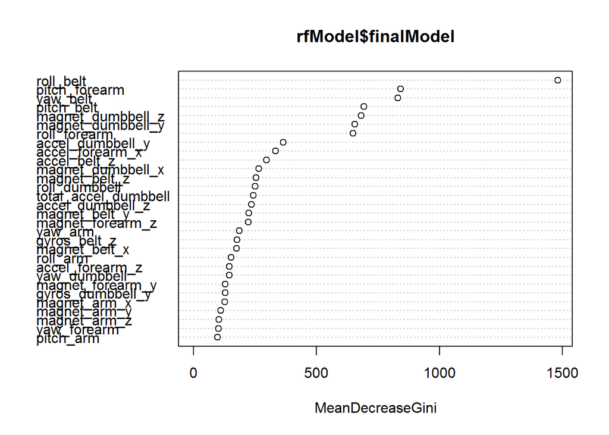

```r
varImpPlot(rfModel$finalModel)
```

Below plot provide the visibility of error against the different values of ntree.

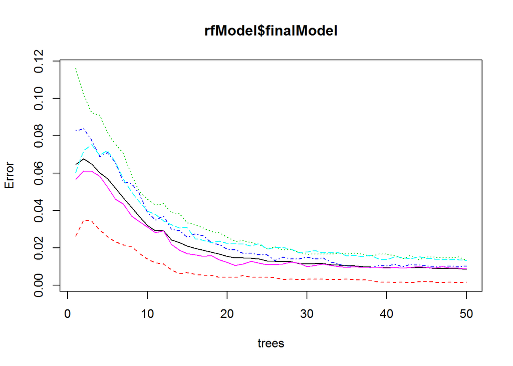

```r
plot(rfModel$finalModel)
```

#### Step 6- **Testing the model on sliced test data**

Now testing the accuracy of rpart and random forest model on the test dataset by constructing the confusion matrix.

##### *Using rpart Model*

```r
predRpart <- predict(rpartModel,test)
confRpart <- table(test$classe,predRpart)
confRpart
```

```
##    predRpart
##        A    B    C    D    E
##   A 1326   34   21    8    6
##   B   71  766   64   22   26
##   C   10   39  755   38   13
##   D   16   24   40  705   19
##   E    6   37   32   40  786
```

```r
accuracyRpart<- sum(diag(confRpart))/sum(confRpart)
print(accuracyRpart)
```

```
## [1] 0.884584
```

##### *Using Random forest Model*

```r
predRf <- predict(rfModel,test)
confRf <- table(test$classe,predRf)
confRf
```

```
##    predRf
##        A    B    C    D    E
##   A 1393    2    0    0    0
##   B    8  940    1    0    0
##   C    0    2  850    3    0
##   D    0    1    7  796    0
##   E    0    1    2    2  896
```

```r
accuracyRf <- sum(diag(confRf))/sum(confRf)
print(accuracyRf)
```

```
## [1] 0.9940865
```

Out of sample error for the Random forest model is under 1% which is far better when compared to ~10-11 % out of sample error using rpart. Also Random forest is a better model against any overfitting.

So I use Random forest model as the final model for prediction.

#### Step 7- **Prediction using Model for the Assginment’s test cases**

Here final prediction is done using Random forest model.

```r
featureset <- colnames(features_training[colSums(is.na(features_training)) == 0])

testCase <- testing[featureset[featureset!='classe']]
ans <- predict(rfModel, newdata=testCase)
ans
```

```
##  [1] B A B A A E D B A A B C B A E E A B B B
## Levels: A B C D E
```

#### Step 8- **Generating text files for Prediction**

```r
pml_write_files = function(x){
  n = length(x)
  for(i in 1:n){
    filename = paste0("problem_id_",i,".txt")
    write.table(x[i],file=filename,quote=FALSE,row.names=FALSE,col.names=FALSE)
  }
}
pml_write_files(ans)
```